# Stastical Analysis of Microarray Data

Aina Montalban

6/8/2019

# Analysis of Microarray Data

This is a RMarkdown document with the code for the Analysis of Microarray Data. The following data analysis follows a pipeline of ordered steps: data capture, quality check, normalization, filtering, selection of differentially expressed genes, annotation and functional comparison.

The data chosen for this analysis is a study with the next title: “*Genome-wide analysis of uterine natural killer cell gene expression from control diet-fed and high fat diet-fed female mice in early pregnancy*” and the GEO accession number is *GSE124927*.

The link which you can find more information is: “https://www.ncbi.nlm.nih.gov/geo/query/acc.cgi?acc=GSE124927”.

The aim of the study is to identify differentially expressed genes and pathways in uterine natural killer cells affected by maternal diet and obesity in pregnancy.

## Working Directory

```r
workingDir <-getwd()
dataDir <- file.path(workingDir, "dades")
resultsDir <- file.path(workingDir, "results")
setwd(resultsDir)
```

```r
#if (!require(BiocManager)) install.packages("BiocManager")

installifnot <- function (pkg){
  if (!require(pkg, character.only=T)){
    BiocManager::install(pkg)
}else{
  require(pkg, character.only=T)
  }
}

installifnot("pd.clariom.s.mouse")
installifnot("oligo")
installifnot("limma")
installifnot("Biobase")
installifnot("gridSVG")
installifnot("ReactomePA")
#installifnot("arrayQualityMetrics")
installifnot("genefilter")
installifnot("multtest")
installifnot("annotate")
installifnot("xtable")
installifnot("gplots")
installifnot("scatterplot3d")
```

## Data capture from text files

The first step in every analysis is to read the target file and the CEL files.

### Targets

There are 5 columns on the targets file:

1. Column called *sampleName*, which contains the name of the CEL files.
2. Column called *group*, which contains the type of diet that is given to the mouse.
3. Column called *replicate*, which contains the individual replicate.
4. Column called *shortName*, which contains short names of the groups.
5. Column called *color*, which contains a list of numbers useful for the the plots.

```r
targets <- read.csv(file = (file.path(dataDir,"targets.txt")),header = TRUE, sep = "")
targets
```

```
##    sampleName                                        group replicate
## 1  GSM3559494                             Control_diet_fed     11_1B
## 2  GSM3559495           High_fat_dietfed_Diet-indued_obese     13_6C
## 3  GSM3559496                             Control_diet_fed     14_3A
## 4  GSM3559497           High_fat_dietfed_Diet-indued_obese    15_10B
## 5  GSM3559498 High_fat_dietfed_Diet-indued_obese_resistant     16_4D
## 6  GSM3559499 High_fat_dietfed_Diet-indued_obese_resistant     17_4C
## 7  GSM3559500           High_fat_dietfed_Diet-indued_obese     18_2C
## 8  GSM3559501           High_fat_dietfed_Diet-indued_obese      2_6B
## 9  GSM3559502                             Control_diet_fed    20_19E
## 10 GSM3559503                             Control_diet_fed    24_13D
## 11 GSM3559504                             Control_diet_fed    26_17A
## 12 GSM3559505                             Control_diet_fed    27_13B
## 13 GSM3559506           High_fat_dietfed_Diet-indued_obese      3_4E
## 14 GSM3559507           High_fat_dietfed_Diet-indued_obese    30_18C
```

[output cut: 27 more lines]

It is important to remark that I have three groups named in the following way:

- Control-diet: CD
- High-Fat Diet-Indued obese: HF
- High-Fat Diet-Indued obese resistant: HF_RES

### CEL files

```r
CELfiles <- list.celfiles(file.path(dataDir))
CELfiles
rawData <- read.celfiles(file.path(dataDir,CELfiles))
```

## Quality assessment of raw data

Once the raw data is readed, we need to check if the data have enough quality for normalizition. We should do with some plots, like boxplots, hierarquical clustering and PCA.

```r
# Select sample names and colors
sampleNames <- as.character(targets$shortName)
sampleColor <- as.character(targets$Colors)
```

### Boxplot

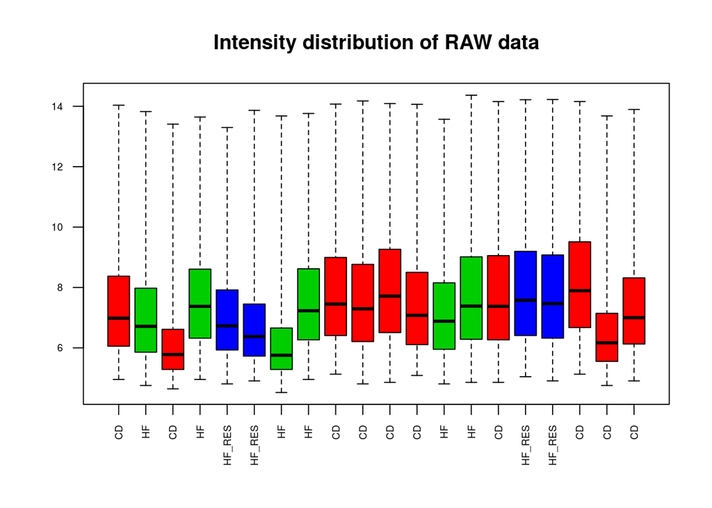

```r
boxplot(rawData, which="all",las=2, main="Intensity distribution of RAW data",
       cex.axis=0.6, col=sampleColor, names=sampleNames)
```

### Hierarquical Clustering

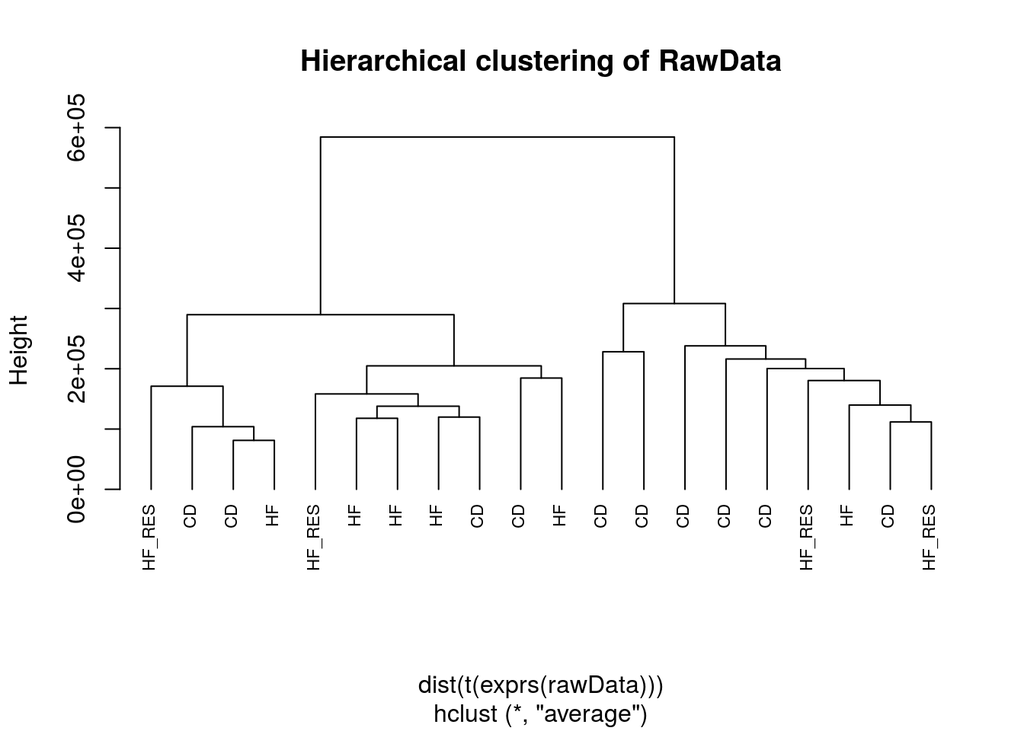

```r
clust.euclid.average <- hclust(dist(t(exprs(rawData))),method="average")
plot(clust.euclid.average, labels=sampleNames, main="Hierarchical clustering of RawData",
     cex=0.7,  hang=-1)
```

### Principal Component Analysis

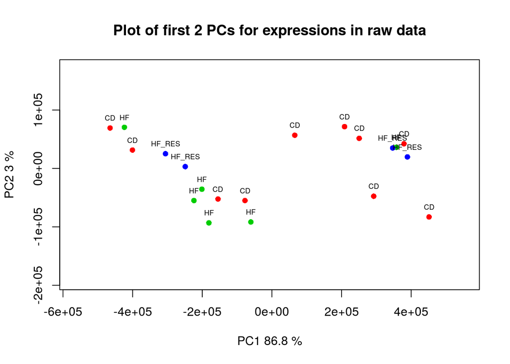

```r
plotPCA <- function ( X, labels=NULL, colors=NULL, dataDesc="", scale=FALSE, formapunts=NULL, myCex=0.8,...)
{
  pcX<-prcomp(t(X), scale=scale) # o prcomp(t(X))
  loads<- round(pcX$sdev^2/sum(pcX$sdev^2)*100,1)
  xlab<-c(paste("PC1",loads[1],"%"))
  ylab<-c(paste("PC2",loads[2],"%"))
  if (is.null(colors)) colors=1
  plot(pcX$x[,1:2],xlab=xlab,ylab=ylab, col=colors, pch=formapunts,
       xlim=c(min(pcX$x[,1])-100000, max(pcX$x[,1])+100000),ylim=c(min(pcX$x[,2])-100000, max(pcX$x[,2])+100000))
  text(pcX$x[,1],pcX$x[,2], labels, pos=3, cex=myCex)
  title(paste("Plot of first 2 PCs for expressions in", dataDesc, sep=" "), cex=0.8)
}
plotPCA(exprs(rawData), labels=sampleNames, dataDesc="raw data", colors=sampleColor,
        formapunts=c(rep(16,4)), myCex=0.6)
```

## Data Normalization

Once we have studied the raw Data, we should normalize it. The normalization consists in three steps: * Background correcting * Normalizing * Calculating Expression

```r
eset_rma<-rma(rawData)
```

```
## Background correcting
## Normalizing
## Calculating Expression
```

```r
write.exprs(eset_rma, file.path(resultsDir, "NormData.txt"))
```

## Quality assessment of normalized data

The same quality check we have done with the data, we can do it with the Normalized data.

### Boxplot

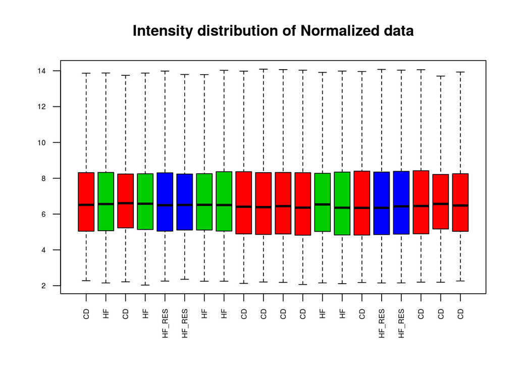

```r
boxplot(eset_rma, las=2, main="Intensity distribution of Normalized data", cex.axis=0.6,
        col=sampleColor, names=sampleNames)
```

### Hierarquical Clustering

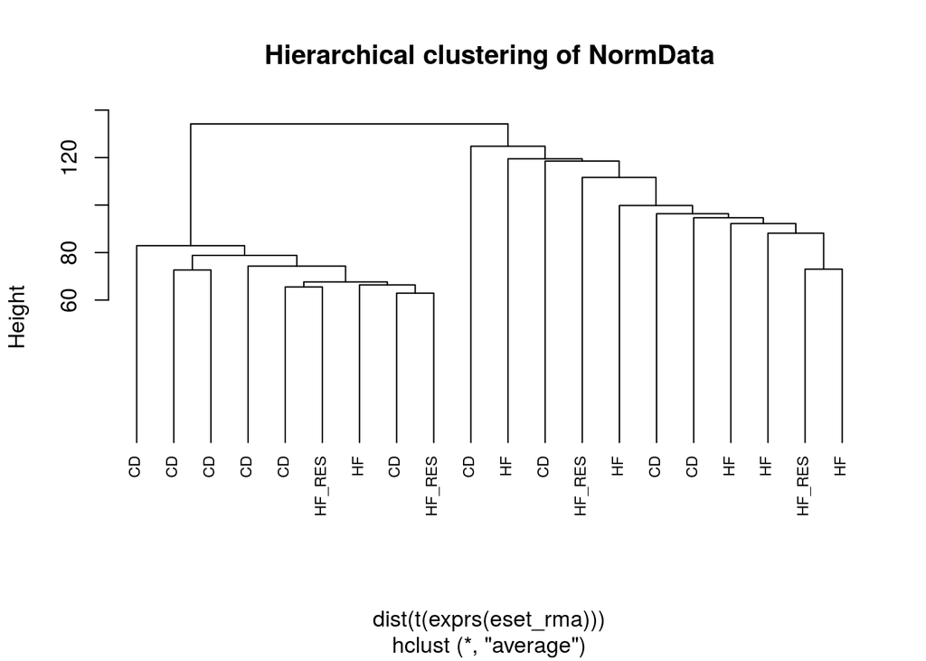

```r
clust.euclid.average <- hclust(dist(t(exprs(eset_rma))),method="average")
plot(clust.euclid.average, labels=sampleNames, main="Hierarchical clustering of NormData",
     cex=0.7,  hang=-1)
```

### Principal Component Analysis

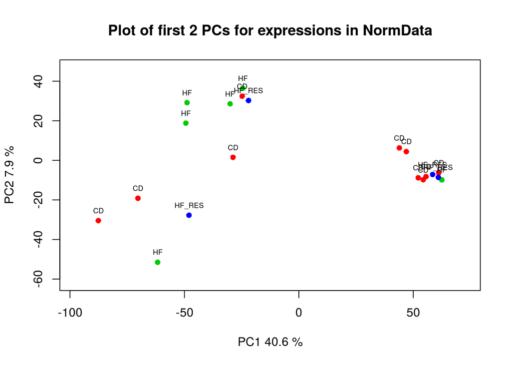

```r
#PRINCIPAL COMPONENT ANALYSIS
plotPCA <- function ( X, labels=NULL, colors=NULL, dataDesc="", scale=FALSE, formapunts=NULL, myCex=0.8,...)
{
  pcX<-prcomp(t(X), scale=scale) # o prcomp(t(X))
  loads<- round(pcX$sdev^2/sum(pcX$sdev^2)*100,1)
  xlab<-c(paste("PC1",loads[1],"%"))
  ylab<-c(paste("PC2",loads[2],"%"))
  if (is.null(colors)) colors=1
  plot(pcX$x[,1:2],xlab=xlab,ylab=ylab, col=colors, pch=formapunts,
       xlim=c(min(pcX$x[,1])-10, max(pcX$x[,1])+10),ylim=c(min(pcX$x[,2])-10, max(pcX$x[,2])+10))
  text(pcX$x[,1],pcX$x[,2], labels, pos=3, cex=myCex)
  title(paste("Plot of first 2 PCs for expressions in", dataDesc, sep=" "), cex=0.8)
}

plotPCA(exprs(eset_rma), labels=sampleNames, dataDesc="NormData", colors=sampleColor,
        formapunts=c(rep(16,4)), myCex=0.6)
```

## Detecting Most Variable Genes

[figure not shown]

```r
sds <- apply (exprs(eset_rma), 1, sd)
sdsO<- sort(sds)
plot(1:length(sdsO), sdsO, main="Distribution of variability for all genes",sub="Vertical lines represent 90% and 95% percentiles",
       xlab="Gene index (from least to most variable)",
       ylab="Standard deviation")
```

```r
#abline(v=length(sds)*c(0.9,0.95))
```

## Filtering data

Now, we need need to filter the genes whose variability can be attributed to random variation.

```r
annotation(eset_rma) <- "clariomsmousetranscriptcluster.db"
eset_filtered <- nsFilter(eset_rma, var.func=IQR,
         var.cutoff=0.75, var.filter=TRUE,
         filterByQuantile=TRUE)
print(eset_filtered$filter.log$numLowVar)
```

```
## [1] 15222
```

```r
print(eset_filtered$eset)
```

```
## ExpressionSet (storageMode: lockedEnvironment)
## assayData: 5074 features, 20 samples
##   element names: exprs
## protocolData
##   rowNames: GSM3559494_11_1B.CEL GSM3559495_13_6C.CEL ...
##     GSM3559513_9_7E.CEL (20 total)
##   varLabels: exprs dates
##   varMetadata: labelDescription channel
## phenoData
##   rowNames: GSM3559494_11_1B.CEL GSM3559495_13_6C.CEL ...
##     GSM3559513_9_7E.CEL (20 total)
##   varLabels: index
##   varMetadata: labelDescription channel
## featureData: none
## experimentData: use 'experimentData(object)'
## Annotation: clariomsmousetranscriptcluster.db
```

After filtering we obtain only 5074 genes left.

## Differential Expressed Genes Selection

### Design Matrix

```r
#CONTRAST MATRIX.lINEAR MODEL
treat <- targets$shortName
lev <- factor(treat, levels = unique(treat))
design <-model.matrix(~ 0+targets$shortName)
rownames(design)<- targets$sampleName
colnames(design)<-c("CD", "HF", "HF_RES")
print(design)
```

```
##            CD HF HF_RES
## GSM3559494  1  0      0
## GSM3559495  0  1      0
## GSM3559496  1  0      0
## GSM3559497  0  1      0
## GSM3559498  0  0      1
## GSM3559499  0  0      1
## GSM3559500  0  1      0
## GSM3559501  0  1      0
## GSM3559502  1  0      0
## GSM3559503  1  0      0
## GSM3559504  1  0      0
## GSM3559505  1  0      0
## GSM3559506  0  1      0
## GSM3559507  0  1      0
## GSM3559508  1  0      0
## GSM3559509  0  0      1
## GSM3559510  0  0      1
## GSM3559511  1  0      0
## GSM3559512  1  0      0
## GSM3559513  1  0      0
## attr(,"assign")
## [1] 1 1 1
## attr(,"contrasts")
## attr(,"contrasts")$`targets$shortName`
## [1] "contr.treatment"
```

### Contrast Matrix

```r
cont.matrix1 <- makeContrasts(
  CD.vs.HF = CD- HF,
  HF.vs.HF_RES = HF-HF_RES,
  CD.vs.HF_RES = CD-HF_RES,
  levels = design)
cont.matrix1
```

```
##         Contrasts
## Levels   CD.vs.HF HF.vs.HF_RES CD.vs.HF_RES
##   CD            1            0            1
##   HF           -1            1            0
##   HF_RES        0           -1           -1
```

### Model fit

```r
#MODEL FIT
fit1 <- lmFit(eset_filtered$eset, design)
fit.main1 <- contrasts.fit(fit1, cont.matrix1)
fit.main1 <- eBayes(fit.main1)
```

## Identification of differentially expressed genes

```r
comparison1 <- "CDvsHF"
#FILTER BY FALSE DISCOVERY RATE AND FOLD CHANGE
topTab_CDvsHF <- topTable(fit.main1, number=nrow(fit.main1), coef = "CD.vs.HF", adjust="fdr", lfc = 1)
```

For comparison 1 (CDvsHF) the genes that change their expression are:

```r
head(topTab_CDvsHF)
```

```
##                       logFC  AveExpr         t     P.Value adj.P.Val
## TC0600003067.mm.2  1.305445 4.575891  3.248084 0.003082603 0.6953256
## TC1100000009.mm.2 -1.384024 8.192432 -2.867140 0.007903490 0.6953256
## TC0200002295.mm.2  1.271515 9.641467  2.747426 0.010528885 0.6953256
## TC0200004663.mm.2  2.123856 6.808145  2.726762 0.011057815 0.6953256
## TC0500000842.mm.2  1.006236 5.462193  2.668990 0.012671740 0.6953256
## TC0500001808.mm.2 -1.130501 6.835055 -2.593398 0.015116610 0.6953256
##                           B
## TC0600003067.mm.2 -4.164815
## TC1100000009.mm.2 -4.250226
## TC0200002295.mm.2 -4.276892
## TC0200004663.mm.2 -4.281476
## TC0500000842.mm.2 -4.294258
## TC0500001808.mm.2 -4.310892
```

```r
comparison2 <- "HFvsHF_RES"
#minimum absolute log2-fold-change required.
topTab_HFvsHF_RES <- topTable(fit.main1, number=nrow(fit.main1), coef = "HF.vs.HF_RES", adjust="fdr", lfc = 1)
```

For comparison 2 (HFvsHF_RES) the genes that change their expression are:

```r
head(topTab_HFvsHF_RES)
```

```
##                       logFC  AveExpr         t     P.Value adj.P.Val
## TC1300000293.mm.2 -1.491938 6.079582 -3.503879 0.001605011 0.8071206
## TC0500000842.mm.2 -1.577517 5.462193 -3.347428 0.002396497 0.8071206
## TC0900001592.mm.2  1.192807 5.202882  3.224339 0.003272664 0.8071206
## TC1900001464.mm.2 -1.975288 7.177753 -3.220238 0.003306611 0.8071206
## TC1300000019.mm.2 -1.170914 7.239073 -3.073266 0.004772586 0.8071206
## TC0500000229.mm.2 -1.037176 6.790204 -2.956968 0.006353774 0.8071206
##                           B
## TC1300000293.mm.2 -4.270064
## TC0500000842.mm.2 -4.293122
## TC0900001592.mm.2 -4.311367
## TC1900001464.mm.2 -4.311976
## TC1300000019.mm.2 -4.333824
## TC0500000229.mm.2 -4.351114
```

```r
comparison3 <- "CDvsHF_RES"
topTab_CDvsHF_RES <- topTable(fit.main1, number=nrow(fit.main1), coef = "CD.vs.HF_RES", adjust="fdr", lfc = 1)
```

For comparison 3 (CDvsHF_RES) the genes that change their expression are:

```r
head(topTab_CDvsHF_RES)
```

```
##                       logFC   AveExpr         t    P.Value adj.P.Val
## TC1300000293.mm.2 -1.113780  6.079582 -2.854026 0.00815762 0.9998259
## TC1900001464.mm.2 -1.060867  7.177753 -1.887031 0.06986843 0.9998259
## TC0500000835.mm.2 -1.006711  6.148476 -1.627491 0.11515959 0.9998259
## TC0700003914.mm.2 -1.304434 10.338581 -1.250905 0.22161918 0.9998259
## TC0700003912.mm.2 -1.128964  8.717963 -1.197586 0.24140738 0.9998259
##                           B
## TC1300000293.mm.2 -4.326911
## TC1900001464.mm.2 -4.486737
## TC0500000835.mm.2 -4.524129
## TC0700003914.mm.2 -4.571503
## TC0700003912.mm.2 -4.577440
```

## Annotation

We also need to associate the information from the tables above with familar names, such as Gene Symbol, Gene Description or Uniprot.

```r
all_anota<-data.frame(exprs(eset_rma))
Annot <- data.frame(SYMBOL=sapply(contents(clariomsmousetranscriptclusterSYMBOL), paste, collapse=", "),
                    DESC=sapply(contents(clariomsmousetranscriptclusterGENENAME), paste, collapse=", "),
                    UNIPROT=sapply(contents(clariomsmousetranscriptclusterUNIPROT), paste, collapse=", "),
                    ENTREZID=sapply(contents(clariomsmousetranscriptclusterENTREZID), paste, collapse=", "))
Annot<-Annot[!Annot$SYMBOL=="NA",]
Annot<-Annot[!Annot$DESC=="NA",]
Annot<-Annot[!Annot$UNIPROT=="NA",]
Annot<-Annot[!Annot$ENTREZID=="NA",]
anotaGenes <- merge(Annot,all_anota, by.x=0,by.y=0)
write.table(anotaGenes, file ="data.ann.txt",sep="\t")
rownames(anotaGenes) <- anotaGenes[,1]
anotaGenes <- anotaGenes[,-1]
```

Finally, for each comparison we need to annotate the genes that are differentially expressed. However, in the tables above we can see that the adjusted p-values are not quite good, in other words, they are not significant.

### Comparison 1: Control-diet vs Diet-Indued

```r
## Comparison 1
anotaGenes.end1 <- merge(anotaGenes, topTab_CDvsHF, by.x=0,by.y=0)
topTab.end1 <- merge(anotaGenes, topTab_CDvsHF, by.x=0,by.y=0)
#reordenamos las columnas
#topTab.end1 <- anotaGenes.end1[,c(1:3,12:17,4:11)]
topTab.end1 <- topTab.end1[order(-topTab.end1$B),]
rownames(topTab.end1) <- topTab.end1[,1]
topTab.end1 <- topTab.end1[, -1]
write.csv(topTab.end1, file = file.path(resultsDir,"TopTable_comp1.end.csv"))
```

```r
head(topTab.end1[,1:3])
```

```
##                    SYMBOL
## TC0600003067.mm.2  Rimklb
## TC1100000009.mm.2 Pik3ip1
## TC0200002295.mm.2     H13
## TC0200004663.mm.2    Erv3
## TC0500000842.mm.2    Ppbp
## TC0500001808.mm.2    Pan3
##                                                                       DESC
## TC0600003067.mm.2 ribosomal modification protein rimK-like family member B
## TC1100000009.mm.2          phosphoinositide-3-kinase interacting protein 1
## TC0200002295.mm.2                                    histocompatibility 13
## TC0200004663.mm.2                         endogenous retroviral sequence 3
## TC0500000842.mm.2                               pro-platelet basic protein
## TC0500001808.mm.2               PAN3 poly(A) specific ribonuclease subunit
##                          UNIPROT
## TC0600003067.mm.2         Q80WS1
## TC1100000009.mm.2         Q7TMJ8
## TC0200002295.mm.2 Q9D8V0, Q6PGJ8
## TC0200004663.mm.2         Q9DAX3
## TC0500000842.mm.2         Q9EQI5
## TC0500001808.mm.2 Q640Q5, H3BKF3
```

### Comparison 2: Diet-Indued vs DIet-Indued Resistance

```r
## Comparison 2
anotaGenes.end2 <- merge(anotaGenes, topTab_HFvsHF_RES, by.x=0,by.y=0)
#reordenamos las columnas
topTab.end2 <- anotaGenes.end2
topTab.end2 <- topTab.end2[order(-topTab.end2$B),]

rownames(topTab.end2) <- topTab.end2[,1]
topTab.end2 <- topTab.end2[, -1]
write.csv(topTab.end2, file = file.path(resultsDir,"TopTable_comp2.end.csv"))
```

```r
head(topTab.end2[,1:3])
```

```
##                    SYMBOL                                             DESC
## TC1300000293.mm.2  Prl3d1        prolactin family 3, subfamily d, member 1
## TC0500000842.mm.2    Ppbp                       pro-platelet basic protein
## TC0900001592.mm.2    Ccr8                 chemokine (C-C motif) receptor 8
## TC1900001464.mm.2    Rbp4                retinol binding protein 4, plasma
## TC1300000019.mm.2 Akr1c13         aldo-keto reductase family 1, member C13
## TC0500000229.mm.2 Galnt11 polypeptide N-acetylgalactosaminyltransferase 11
##                              UNIPROT
## TC1300000293.mm.2 A0A286YC78, Q8BNL4
## TC0500000842.mm.2             Q9EQI5
## TC0900001592.mm.2     P56484, Q3ZB17
## TC1900001464.mm.2     H7BWY6, Q00724
## TC1300000019.mm.2     Q571M4, Q8VC28
## TC0500000229.mm.2             Q921L8
```

```r
## Comparison 3
anotaGenes.end3 <- merge(anotaGenes, topTab_HFvsHF_RES, by.x=0,by.y=0)
#reordenamos las columnas
topTab.end3 <- anotaGenes.end3
topTab.end3 <- topTab.end3[order(-topTab.end3$B),]

rownames(topTab.end3) <- topTab.end3[,1]
topTab.end3 <- topTab.end3[, -1]
write.csv(topTab.end3, file = file.path(resultsDir,"TopTable_comp3.end.csv"))
```

```r
head(topTab.end3[,1:3])
```

```
##                    SYMBOL                                             DESC
## TC1300000293.mm.2  Prl3d1        prolactin family 3, subfamily d, member 1
## TC0500000842.mm.2    Ppbp                       pro-platelet basic protein
## TC0900001592.mm.2    Ccr8                 chemokine (C-C motif) receptor 8
## TC1900001464.mm.2    Rbp4                retinol binding protein 4, plasma
## TC1300000019.mm.2 Akr1c13         aldo-keto reductase family 1, member C13
## TC0500000229.mm.2 Galnt11 polypeptide N-acetylgalactosaminyltransferase 11
##                              UNIPROT
## TC1300000293.mm.2 A0A286YC78, Q8BNL4
## TC0500000842.mm.2             Q9EQI5
## TC0900001592.mm.2     P56484, Q3ZB17
## TC1900001464.mm.2     H7BWY6, Q00724
## TC1300000019.mm.2     Q571M4, Q8VC28
## TC0500000229.mm.2             Q921L8
```

In order to observe this more visually, we can perfrorm three volcanos plot of each comparison.

### Volcano Plots

```r
geneSym <- select(clariomsmousetranscriptcluster.db, rownames(fit.main1), c("SYMBOL"))
```

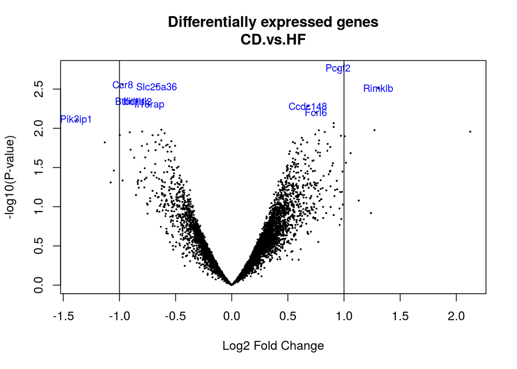

```r
SYMBOLS <- geneSym$SYMBOL


volcanoplot(fit.main1, coef = 1, highlight = 10, names = SYMBOLS,
            main = paste("Differentially expressed genes",
            colnames(cont.matrix1)[1], sep = "\n"))
abline(v = c(-1, 1))
```

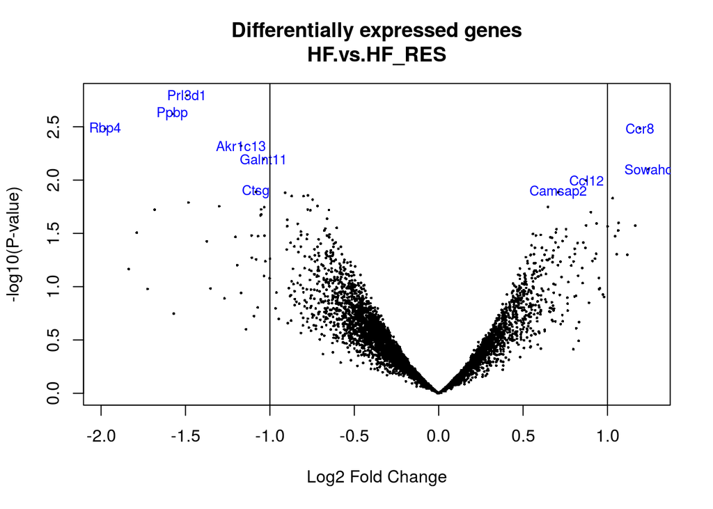

```r
volcanoplot(fit.main1, coef = 2, highlight = 10, names = SYMBOLS,
            main = paste("Differentially expressed genes",
                         colnames(cont.matrix1)[2], sep = "\n"))
abline(v = c(-1, 1))
```

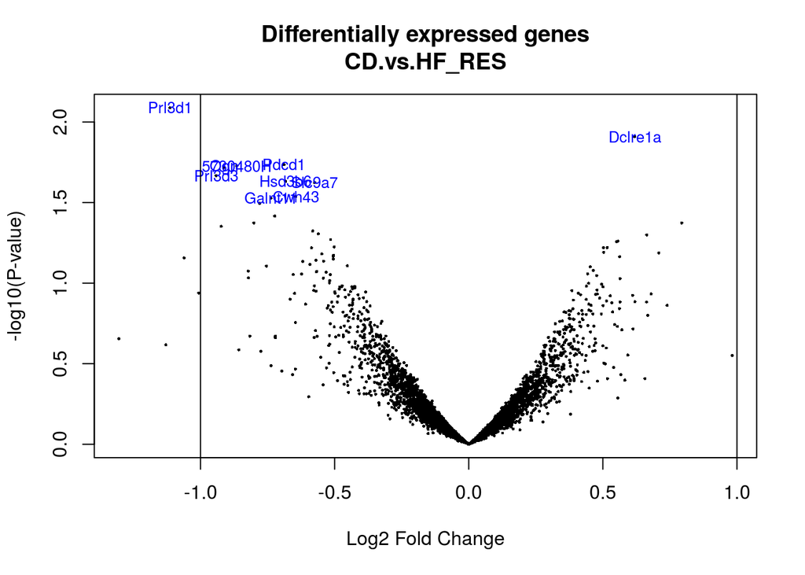

```r
volcanoplot(fit.main1, coef = 3, highlight = 10, names = SYMBOLS,
            main = paste("Differentially expressed genes",
                         colnames(cont.matrix1)[3], sep = "\n"))
abline(v = c(-1, 1))
```

As I have mentioned the p-value is not significant, and we can say that there are no genes significantlly differentially expressed. So, there is no sense to continue the study. Although, in order to learn the following steps of the analysis, I will perform multiple comparisions, but always taking into account that the p-value is not significant.

```r
res <- decideTests(fit.main1, method = "separate", adjust.method = "fdr", p.value = 1, lfc = 1)
sum.res.rows <- apply(abs(res), 1, sum)
res.selected <- res[sum.res.rows!=0,]
print(summary(res))
```

```
##        CD.vs.HF HF.vs.HF_RES CD.vs.HF_RES
## Down          4           34            5
## NotSig     5062         5030         5069
## Up            8           10            0
```

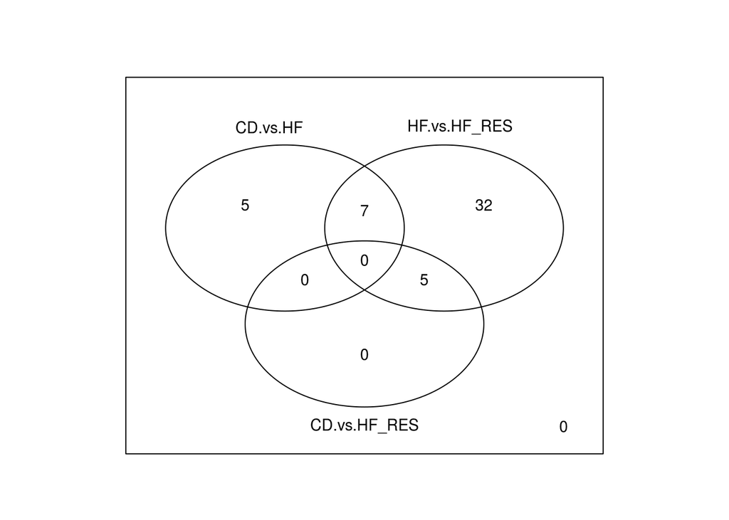

```r
vennDiagram(res.selected[,1:3], cex=0.9)
```